# Exploration DataProducts ShinyProject

Sep

Friday, October 17, 2014

# Exploration DataProducts ShinyProject

## For Developing Data Products - 17/10/2014

# The general plan

## The Initial ideas

- Interactive fractal generation
- Some form of ODE systems - predator/prey maybe?
- Game theory project - prisoners dilema?
- percolalltion and forest fires <– could be a real treat!
- Interactive statistics - plotting distributions
- Black Jack simulator?
- Interactive statistics - Using the General Social Survey Data 1972-2012 [Pick this]

## Why pick the given project?

- Good to get more experience working with data, will overlap with some of the other courses that I’m currently taking.
- I’ve already done most of the other projects in different languages.
- I want to know more about the given data!!

## Need Data?

Yes. The data I’m going to use is from the [ICPSR](http://www.icpsr.umich.edu/icpsrweb/ICPSR/studies/34802/version/1) Here is [a link to the codebook](http://www.icpsr.umich.edu/cgi-bin/file?comp=none&study=34802&ds=1&file_id=1136502&path=ICPSR)

The data is on the large side, as such it will need cutting.

I’ll be starting off with a cleaned data set - from another [Duke Uni] course I’ve been taking, I will however need to cut the data down even further so that it can be easily uploaded for use in the shiny app.

## Aim $\checkmark$

Make a shiny app! Want to have a drop menus for

- Plot type
- variables of interest i.e Var 1 against Var 2 or Var 3 againsts Var 1 etc..
  - This will need a selection process for number of variables user is interested in if two vars you can have these plots.
  - sub section plotting? how about splitting plots by group depending on the users vars of interest?
  - something like: if box plot make subsectioning available?
- I want check box that when turned on outputs a summary of the chosen data cut by groupings.

## Prelim todos (and don’ts)

Philosophy for the project: Keep it small, high quality and interesting. Think 2 mins of use by an average user.

- explore the data and ID vars of interest.
  - keep the number of vars modest! This is a proof of concept not a full flashy product.
- produce a smaller data set for the purpose of this shiny app.
- Make a small map of what the UI should look like and what I want the user to see exactly
- Get the shiny app running locally
- Add documentation
- Upload to github
- get a pitch presentation together about the app 5 slides.

# Some exploration of the data

Start by loading up the Duke cleaned gss data

```r
load("../data/statistics-project-gss.Rdata")
names(gss)
```

```
##   [1] "caseid"   "year"     "age"      "sex"      "race"     "hispanic"
##   [7] "uscitzn"  "educ"     "paeduc"   "maeduc"   "speduc"   "degree"
##  [13] "vetyears" "sei"      "wrkstat"  "wrkslf"   "marital"  "spwrksta"
##  [19] "sibs"     "childs"   "agekdbrn" "incom16"  "born"     "parborn"
##  [25] "granborn" "income06" "coninc"   "region"   "partyid"  "polviews"
##  [31] "relig"    "attend"   "natspac"  "natenvir" "natheal"  "natcity"
##  [37] "natcrime" "natdrug"  "nateduc"  "natrace"  "natarms"  "nataid"
##  [43] "natfare"  "natroad"  "natsoc"   "natmass"  "natpark"  "confinan"
##  [49] "conbus"   "conclerg" "coneduc"  "confed"   "conlabor" "conpress"
##  [55] "conmedic" "contv"    "conjudge" "consci"   "conlegis" "conarmy"
##  [61] "joblose"  "jobfind"  "satjob"   "richwork" "jobinc"   "jobsec"
##  [67] "jobhour"  "jobpromo" "jobmeans" "class"    "rank"     "satfin"
##  [73] "finalter" "finrela"  "unemp"    "govaid"   "getaid"   "union"
##  [79] "getahead" "parsol"   "kidssol"  "abdefect" "abnomore" "abhlth"
##  [85] "abpoor"   "abrape"   "absingle" "abany"    "pillok"   "sexeduc"
##  [91] "divlaw"   "premarsx" "teensex"  "xmarsex"  "homosex"  "suicide1"
##  [97] "suicide2" "suicide3" "suicide4" "fear"     "owngun"   "pistol"
## [103] "shotgun"  "rifle"    "news"     "tvhours"  "racdif1"  "racdif2"
## [109] "racdif3"  "racdif4"  "helppoor" "helpnot"  "helpsick" "helpblk"
```

From the names, there are few that look interesting for analysis * year * age * sex * edu * coninc * religion

## subsetting the data

Make a data table with dplyr

```r
library(dplyr)
gsstbl <- tbl_df(gss[,c("year", "age", "sex", "educ","degree", "coninc", "relig")])
```

Have a look at the structure and summary of the data

```r
str(gsstbl)
```

```
## Classes 'tbl_df', 'tbl' and 'data.frame':    57061 obs. of  7 variables:
##  $ year  : int  1972 1972 1972 1972 1972 1972 1972 1972 1972 1972 ...
##  $ age   : int  23 70 48 27 61 26 28 27 21 30 ...
##  $ sex   : Factor w/ 2 levels "Male","Female": 2 1 2 2 2 1 1 1 2 2 ...
##  $ educ  : int  16 10 12 17 12 14 13 16 12 12 ...
##  $ degree: Factor w/ 5 levels "Lt High School",..: 4 1 2 4 2 2 2 4 2 2 ...
##  $ coninc: int  25926 33333 33333 41667 69444 60185 50926 18519 3704 25926 ...
##  $ relig : Factor w/ 13 levels "Protestant","Catholic",..: 3 2 1 5 1 1 2 3 1 1 ...
```

```r
summary(gsstbl)
```

```
##       year           age           sex             educ
##  Min.   :1972   Min.   :18.0   Male  :25146   Min.   : 0.0
##  1st Qu.:1983   1st Qu.:31.0   Female:31915   1st Qu.:12.0
##  Median :1993   Median :43.0                  Median :12.0
##  Mean   :1992   Mean   :45.7                  Mean   :12.8
##  3rd Qu.:2002   3rd Qu.:59.0                  3rd Qu.:15.0
##  Max.   :2012   Max.   :89.0                  Max.   :20.0
##                 NA's   :202                   NA's   :164
##             degree          coninc              relig
##  Lt High School:11822   Min.   :   383   Protestant:33472
##  High School   :29287   1st Qu.: 18445   Catholic  :13926
##  Junior College: 3070   Median : 35602   None      : 6113
##  Bachelor      : 8002   Mean   : 44503   Jewish    : 1155
##  Graduate      : 3870   3rd Qu.: 59542   Other     :  998
##  NA's          : 1010   Max.   :180386   (Other)   : 1164
##                         NA's   :5829     NA's      :  233
```

## pairs plotting

Have a look at scatter plot pairing the data. As a note the pairs function can take some time so instead take a random sample from our table

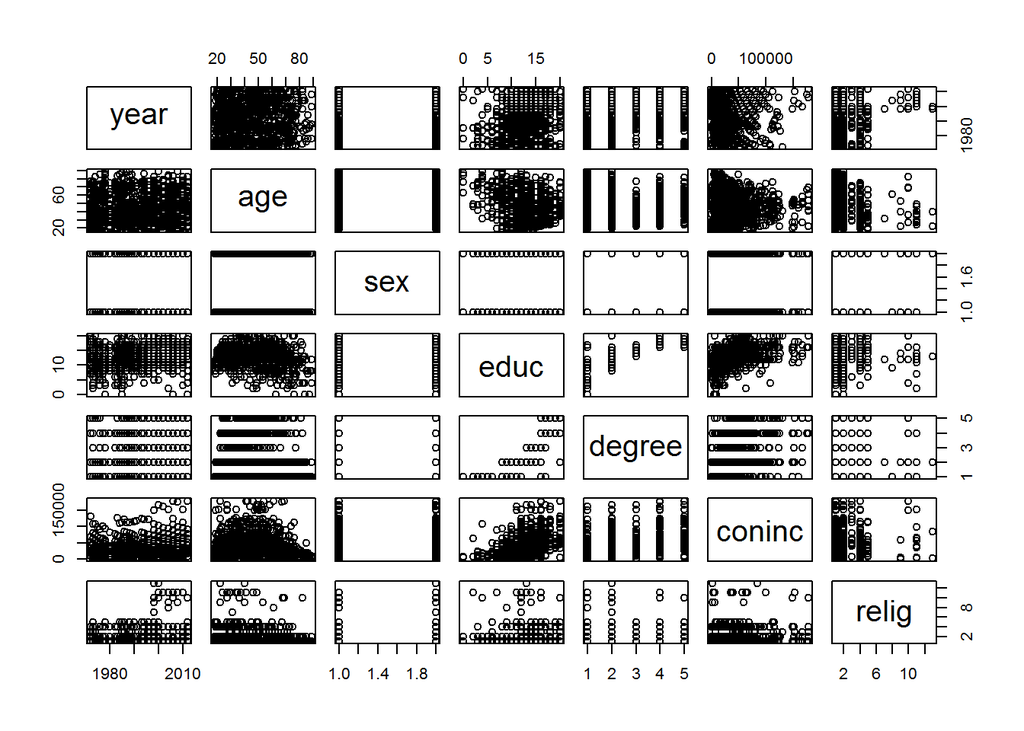

```r
num_rand_rows <- 1000 # randomly sample this many rows
gsstbl %>% sample_n(size=num_rand_rows) %>% pairs
```

## Look at some histograms of interest

A barplot of the highest degree achieved

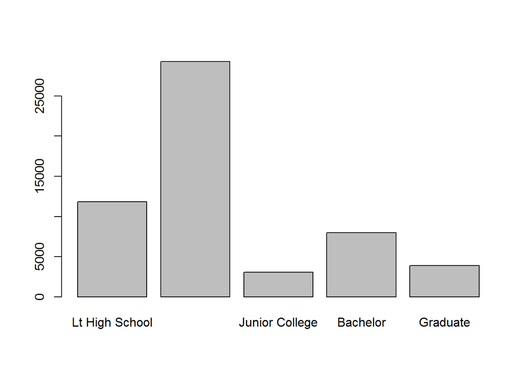

```r
## Alternative to dplyr piping
# barplot( table(gsstbl$degree) )

gsstbl %>% select(degree) %>% table %>% barplot
```

Bar plot of average family income by highest degree

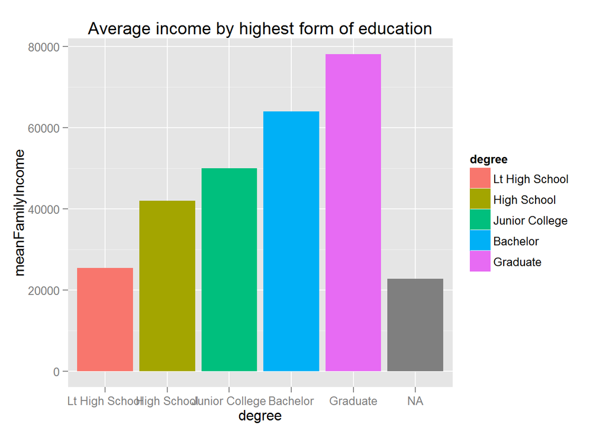

```r
library(ggplot2)
gsstbl %>%
        group_by(degree) %>%
        summarize(meanFamilyIncome=mean(coninc,na.rm=TRUE)) %>%
        ggplot(aes(x=degree,y=meanFamilyIncome,fill=degree)) +
        geom_bar(stat="identity") +
        labs(title="Average income by highest form of education")
```

Q: how has the average family income changed over the years based on your degree

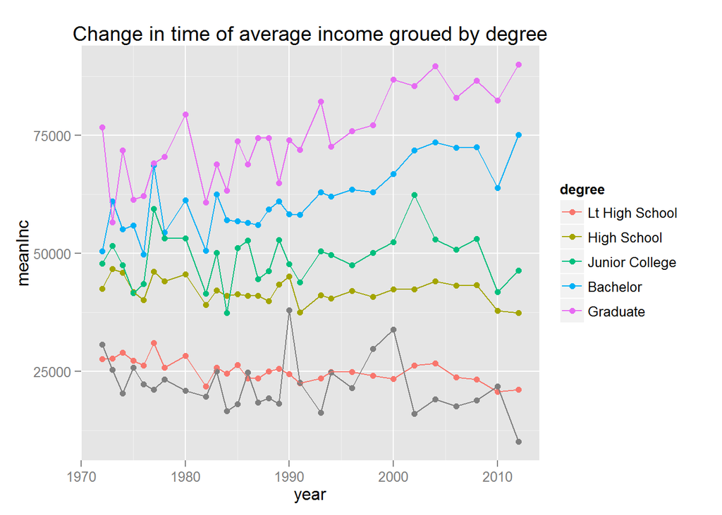

```r
gsstbl %>%
    group_by(year,degree) %>%
    summarize(meanInc=mean(coninc,na.rm=TRUE)) %>%
    ggplot(aes(x=year,y=meanInc, group=degree,color=degree)) +
    geom_point() +
    geom_line() +
    labs(title="Change in time of average income groued by degree")
```